# The 5 W’s (and 1 H) of Birds at Meola Reef Reserve

Frequent trips to the dog park made me realise that I saw and heard more birds than I expected in an urban reserve. This made me curious of what birds species live here and how many there typically were.

So, this story will be an exploration on the **diversity of birds at Meola Reef Reserve (Te Tokaroa)**, an urban reserve located in Western Springs. Data collection was done by myself across the months of March and May of 2025. Here, I look at various species, their abundance and distribution, to ultimately discover the overall bird diversity that lies in Meola Reef Reserve.

By the end of this, hopefully this can make you become more aware and appreciate the wonderful birds that can found in urban areas. Greater awareness from the community can mean we can continue to restore this reserve with the help from Auckland Council and Waitematā Local Board to increase bird diversity!

## But first, WHY birds?

Birds are **so cool**!

They can inform us a lot about the surrounding environmental health and biodiversity!

[figure not shown]

A bird meme of someone only thinking about birds when someone asks what’s on their mind

## The WHO and the WHAT?

The data shows around 7 native and 6 non-native species can be found at the reserve. We can see that typically 3 individuals are found of a bird species in one visit.

Interestingly, you are most likely to find our native welcome swallows in the highest abundance!

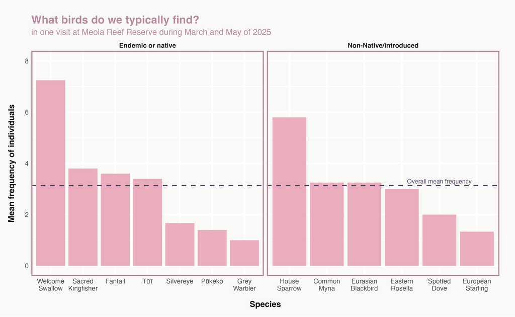

Bar graph comparing the mean frequency of individuals found for various species in one visit at Meola Reef Reserve, split by endemic or native species, and non-native/introduced species

This means we can find a relatively high number of species at Meola Reef Reserve, and are likely to find a few individuals of each species if we do see them!

## The WHERE?

**What are the different habitats at Meola Reef Reserve?** A **closed habitat** is covered by dense vegetation, and provides birds with shelter and resources, whereas an **open habitat** lacks cover and can expose birds to environmental conditions.

It appears that there is an even distribution of birds being found in closed and open habitats.

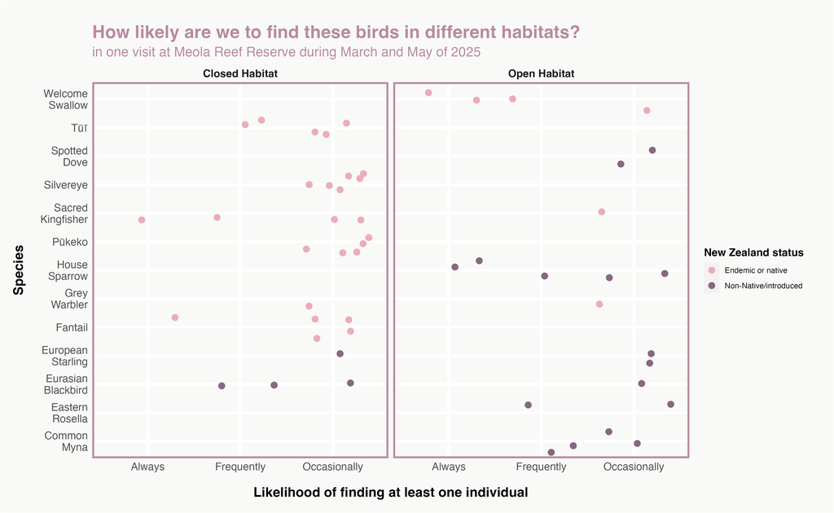

A jitter plot to visualise the likelihood of finding at least one individual of a species in each habitat - closed or open habitat, and points are coloured by whether they are native or non-native species

This means that we can find birds in both the closed and open habitats of Meola Reef Reserve!

Generally, we can find most endemic or native species only occasionally in closed habitats. Whereas, we can find most non-native species either frequently and occasionally in open habitats.

This may be because native species need more protection from predators, like rats and mice, whereas non-native species are able to thrive in a wide range of areas and are less affected by predators.

## The WHEN and most importantly, HOW diverse?

The data seems to show a pattern between March and May (when data collection took place) and ultimately indicate the diversity of birds found at Meola Reef Reserve.

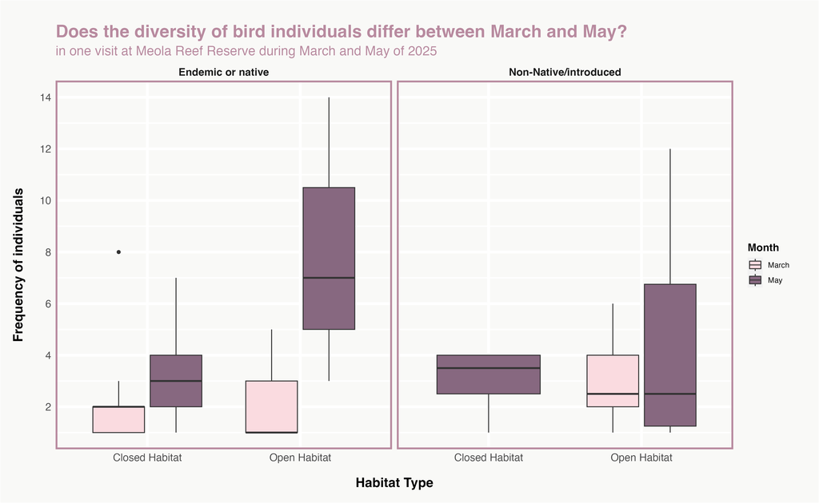

A box plot showing the distribution of the frequency of individuals and what habitat type they are found in with the month they were found, split by endemic or native species, and non-native/introduced species

This indicates Meola Reef Reserve has a moderate diversity of birds.

This means if you visit in May, you may see more birds in each habitat than if you visited in March.

## And finally!

**From all three of my graphs, I found that:**

- Meola Reef Reserve has a moderate diversity of birds, which is typical for urban parks and reserves
- Visiting the reserve in May may result in finding a greater diversity of birds compared to March
- You are likely to find welcome swallows and house sparrows, and it does not matter whether you are in the closed or open habitat areas in the reserve to find birds

**So, in conclusion, all birds are cool, even house sparrows, and we should appreciate them all.**